# R-Ladies Paris: Why, What, Who?

Page Piccinini & Christina Bergmann

October 6, 2016

# Why?

Gender imbalances are real!

# Exhibit 1

Speakers (keynote, debates, invited symposium) at the Society for the Neurobiology of Language conferences 2009-2015

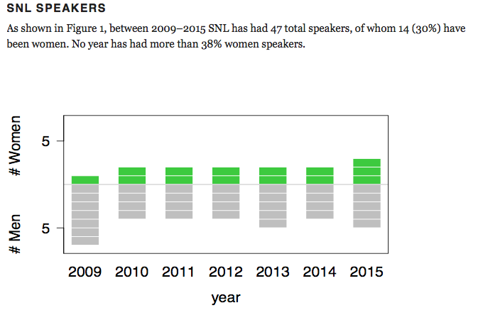

[Source](https://thewinnower.com/papers/3415-speaker-gender-balance-at-society-for-the-neurobiology-of-language-conferences-2009-2015)

# Exhibit 1 cont.

It’s not because there are not enough experts

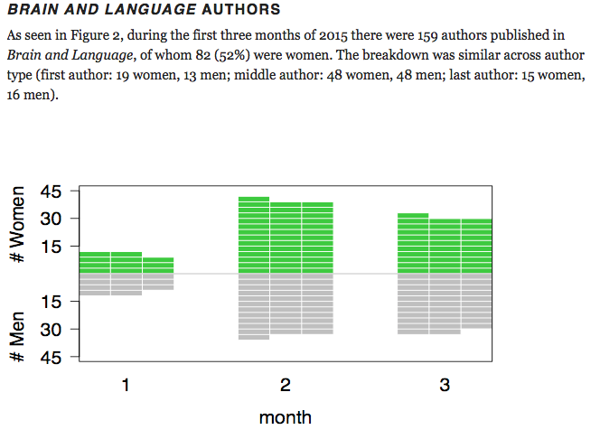

[Source](https://thewinnower.com/papers/3415-speaker-gender-balance-at-society-for-the-neurobiology-of-language-conferences-2009-2015)

# Exhibit 2

49% selected, 37% invited talks

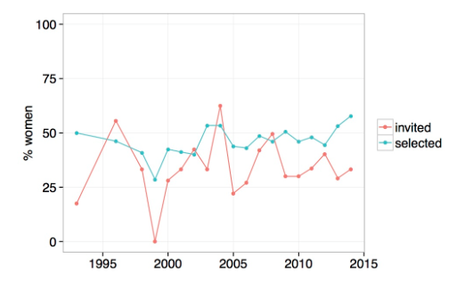

[Source](http://blogs.umass.edu/phonolist/2016/01/05/the-representation-of-women-in-phonological-discussion/)

# Exhibit 3

And, because it’s Nobel Prize week…

[figure not shown]

[Source](https://www.statista.com/chart/2805/nobel-prize-winners-by-gender/)

# Exhibit 4: Our own experiences

[figure not shown]

[Source](https://twitter.com/jengolbeck/status/783287116524642304)

# Exhibit 4: Our own experiences

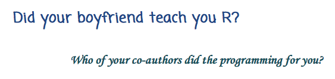

(See also CogTales!)

# But wait!

It’s not just academia!

# Exhibit 4

[figure not shown]

[Source](http://fivethirtyeight.com/live-blog/first-presidential-debate-election-2016/)

# Exhibit 5

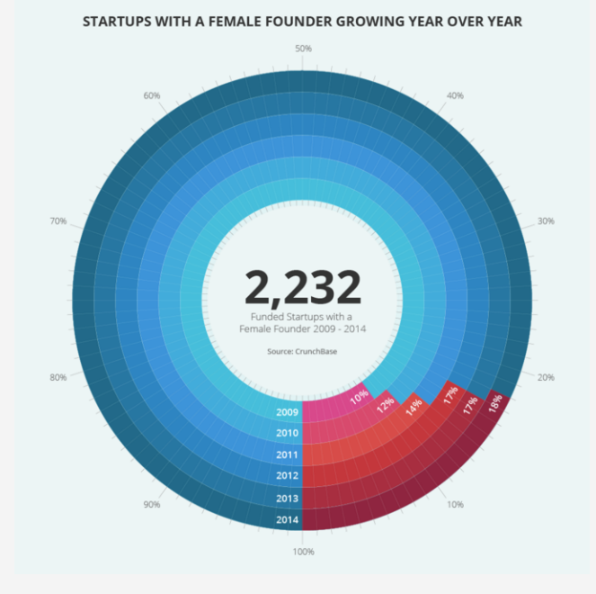

Source

[See also](https://si.wsj.net/public/resources/images/SM-AA934_WOMENs_G_20140818161509.jpg)

# Does R-Ladies help?

Digital fluency helps close the gender wage gap!

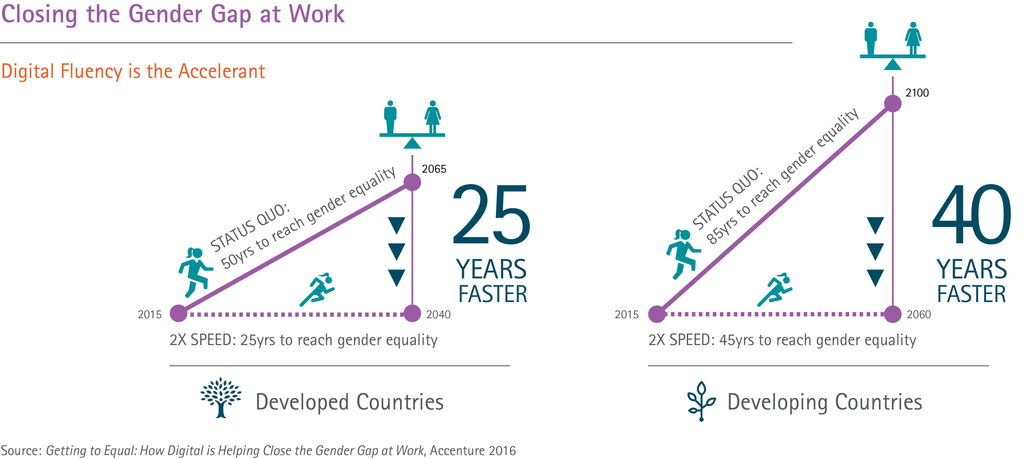

[Source](http://fortune.com/2016/03/03/women-digitally-fluent/?iid=sr-link1)

# Does R-Ladies help?

How’s digital fluency in France and across the globe?

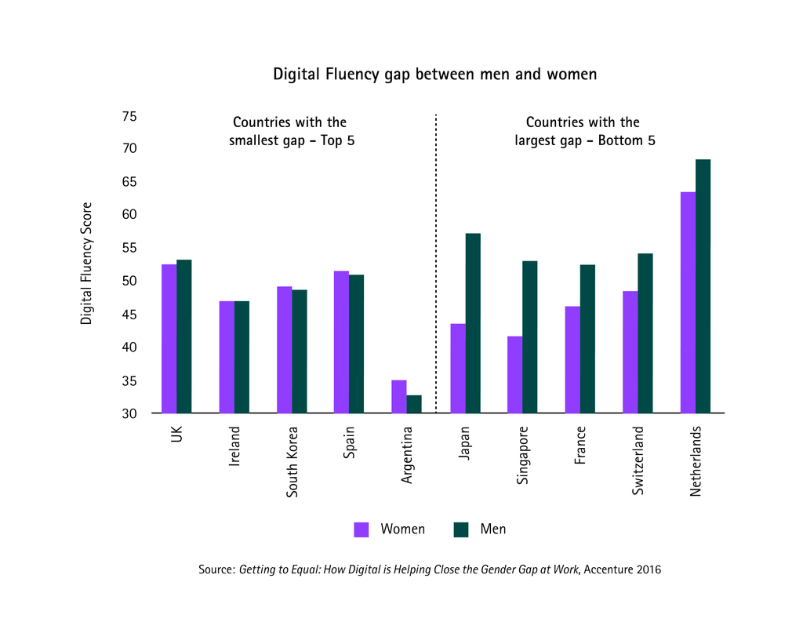

[Source](http://fortune.com/2016/03/03/women-digitally-fluent/?iid=sr-link1)

# Who

R-Ladies: a global organisation with chapters in San Francisco, London, Istanbul…

Paris chapter organized by Page Piccinini (NPI), Christina Bergmann (LSCP), and Diane Beldame (ThinkR)

Currently about 70 members

You are invited, too, independent of your gender identity. Really! Men can come, as long as a member who is also at the meeting vouches for them.

# What are we actually doing?

A monthly meeting, centered around R, with talks / tutorials and social time.

Topics will include:

- Introduction to R and various R-features
- Mentoring (matching up experienced users and beginners, people new to industry and senior folks)
- Discussion of specific packages and tools such as tidyverse, shiny, ggplot2, RMarkdown
- Tutorials e.g., on visualization principles and techniques, data wrangling, analysis techniques

# What are we actually doing?

Concrete suggestions from last night’s inaugural meeting:

- Create a Facebook group
- Organize “Shut up and code” where members can help each other out

# How

Join the meetup.com group and RSVP to the meetings that interest you.

Note, there is a code of conduct. Yes, it’s necessary.

# Sponsors

- R Consortium
- DEC
- CogWorks
- ThinkR
- …